# Examen de estadística multivariable

Luis Enrique García Gómez y Sergio Eduardo Rodríguez Tinoco

# Análisis estadístico multivariado de los pokemon hasta 8tava generación

### Introducción

Pokémon, es una franquicia que originalmente comenzó como un videojuego RPG, pero debido a su popularidad ha logrado expandirse a otros medios de entretenimiento como series de televisión, películas, ropa, entre otros, convirtiéndose en una marca que es reconocida en el mercado mundial.

Cuando el creador, Satoshi Tajiri, era joven, uno de sus pasatiempos favoritos era la recolección y colección de insectos; de ahí surgió la idea de los Pokémon, que son una clase de criaturas inspiradas en animales reales, insectos, objetos, plantas o criaturas mitológicas.

Los jugadores toman el papel Entrenadores Pokémon, algunos objetivos generales son completar la Pokédex mediante la captura y entrenar un equipo de Pokémon poderosos de aquellos que han atrapado para competir contra otros entrenadores.

### Objetivo

Describir a los Pokémon hasta la octava generación, ver si existe alguna relación de cómo están repartidas las estadísticas y ver si existe alguna otra forma de agrupar a los pokémon (agrupados por el tipo: normal, agua, fantasma, fuego, etc)

### Base de datos

La base de datos original está disponible en https://www.kaggle.com/brendan45774/pokmon-index-database?select=pokemon.csv.

Importar datos y filtrar para obtener una base de datos de 7 variables cuantitativas y dos categóricas (en total son 22 registros después de filtrar), se utilizaran los metodos de analisis multivariado adecuados a los datos.

Pokémons con un total de puntos mayor a 550 y puntos de salud mayores a 100.

```r
pokemon <- read.csv("pokemon.csv")
library(dplyr)
pok<-pokemon%>%
  filter(Total>550, HP>100)%>%
  select(Name:Speed)%>%
  distinct(Name, .keep_all = TRUE)
pok
```

| Name | Type | Total | HP | Attack | Defense | Special.Attack | Special.Defense | Speed |
| --- | --- | --- | --- | --- | --- | --- | --- | --- |
| Mega Kangaskhan | NORMAL | 590 | 105 | 125 | 100 | 60 | 100 | 100 |
| Mewtwo | PSYCHIC | 680 | 106 | 110 | 90 | 154 | 90 | 130 |
| Mega Mewtwo X | PSYCHIC | 780 | 106 | 190 | 100 | 154 | 100 | 130 |
| Mega Mewtwo Y | PSYCHIC | 780 | 106 | 150 | 70 | 194 | 120 | 140 |
| Entei | FIRE | 580 | 115 | 115 | 85 | 90 | 75 | 100 |
| Lugia | PSYCHIC | 680 | 106 | 90 | 130 | 90 | 154 | 110 |
| Ho-oh | FIRE | 680 | 106 | 130 | 90 | 110 | 154 | 90 |
| Slaking | NORMAL | 670 | 150 | 160 | 100 | 95 | 65 | 100 |
| Rayquaza | DRAGON | 680 | 105 | 150 | 90 | 150 | 90 | 95 |
| Garchomp | DRAGON | 600 | 108 | 130 | 95 | 80 | 85 | 102 |

[output cut: 12 more lines]

#### Pokemon Legendarios

Hay que hacer un particular énfasis a los pokémon legendarios que se destacan en comparación con el resto de los Pokémon, se caracterizan sobre todo por su enorme poder.

Destaquemos a uno de ellos conocido como mewtwo, al ser el resultado de un experimento que desembocó en su creación, su versión X y su versión Y ; considerado en el anime y en los videojuegos como uno de los pokémon más fuertes, se hace esta mención ya que seguramente lo podamos ver reflejado en los resultados de clusterización.

[figure not shown]

### Estadística descriptiva.

#### Medidas de tendencia central, cuartiles y medidas de dispersión

```r
stdev<-pok%>%summarise(sd(Total), sd(HP), sd(Attack), sd(Defense), sd(Special.Attack), sd(Special.Defense), sd(Speed))
names(stdev)<-names(pok[,3:9])
varianza<-stdev^2
```

```r
summary(pok[,3:9])
```

```
     Total             HP            Attack         Defense
 Min.   :580.0   Min.   :105.0   Min.   : 70.0   Min.   : 70.0
 1st Qu.:662.5   1st Qu.:106.0   1st Qu.:116.2   1st Qu.: 90.0
 Median :680.0   Median :112.5   Median :130.0   Median :100.0
 Mean   :672.3   Mean   :118.5   Mean   :130.5   Mean   :101.2
 3rd Qu.:695.0   3rd Qu.:125.0   3rd Qu.:150.0   3rd Qu.:113.8
 Max.   :780.0   Max.   :150.0   Max.   :190.0   Max.   :130.0
 Special.Attack  Special.Defense     Speed
 Min.   : 60.0   Min.   : 65.0   Min.   : 85.0
 1st Qu.: 90.0   1st Qu.: 90.0   1st Qu.: 95.0
 Median :120.0   Median : 99.0   Median : 99.0
 Mean   :116.1   Mean   :103.6   Mean   :102.4
 3rd Qu.:131.0   3rd Qu.:117.5   3rd Qu.:101.5
 Max.   :194.0   Max.   :154.0   Max.   :140.0
```

Varianza

```r
varianza
```

| Total | HP | Attack | Defense | Special.Attack | Special.Defense | Speed |
| --- | --- | --- | --- | --- | --- | --- |
| 2827.922 | 227.6883 | 825.974 | 215.9654 | 1165.361 | 489.5866 | 214.1472 |

Desviación estándar

```r
stdev
```

| Total | HP | Attack | Defense | Special.Attack | Special.Defense | Speed |
| --- | --- | --- | --- | --- | --- | --- |
| 53.17821 | 15.08934 | 28.73976 | 14.69576 | 34.13739 | 22.1266 | 14.63377 |

#### Estandarización porque se desconoce si las variables están en la misma escala

```r
pok.scale<-scale(pok[,3:9])
pok.scale<-as.data.frame(pok.scale)
```

#### Medidas de tendencia central y cuartiles con los datos estandarizados

```r
summary(pok.scale)
```

```
     Total               HP              Attack
 Min.   :-1.7352   Min.   :-0.8917   Min.   :-2.10668
 1st Qu.:-0.1838   1st Qu.:-0.8254   1st Qu.:-0.49741
 Median : 0.1453   Median :-0.3946   Median :-0.01898
 Mean   : 0.0000   Mean   : 0.0000   Mean   : 0.00000
 3rd Qu.: 0.4274   3rd Qu.: 0.4338   3rd Qu.: 0.67692
 Max.   : 2.0258   Max.   : 2.0906   Max.   : 2.06872
    Defense         Special.Attack    Special.Defense
 Min.   :-2.12182   Min.   :-1.6444   Min.   :-1.7441
 1st Qu.:-0.76089   1st Qu.:-0.7656   1st Qu.:-0.6142
 Median :-0.08042   Median : 0.1132   Median :-0.2075
 Mean   : 0.00000   Mean   : 0.0000   Mean   : 0.0000
 3rd Qu.: 0.85523   3rd Qu.: 0.4354   3rd Qu.: 0.6286
 Max.   : 1.96099   Max.   : 2.2809   Max.   : 2.2782
     Speed
 Min.   :-1.18655
 1st Qu.:-0.50319
 Median :-0.22985
 Mean   : 0.00000
 3rd Qu.:-0.05902
 Max.   : 2.57188
```

#### Gráficas de caja y bigotes

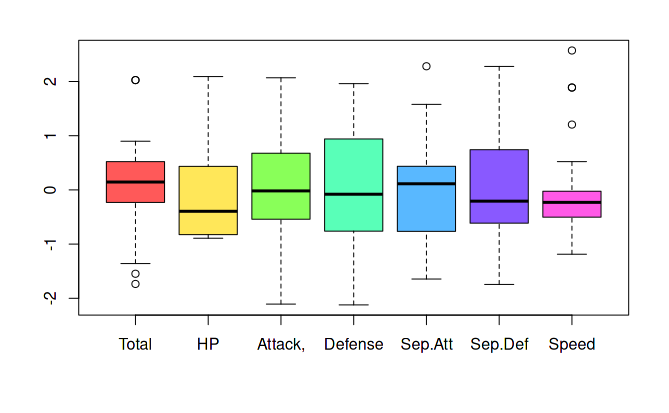

```r
boxplot(pok.scale$Total, pok.scale$HP, pok.scale$Attack, pok.scale$Defense, pok.scale$Special.Attack,
        pok.scale$Special.Defense, pok.scale$Speed, names = c("Total","HP","Attack,","Defense","Sep.Att","Sep.Def","Speed"),col = rainbow(7,s = 0.65))
```

### Observaciones:

- Total tiene datos atípicos y está sesgada a la izquierda.
- HP está sesgada a la derecha.
- Attack y Deffense parecen ser distribuciones normales.
- Special.Attack tiene un dato atípico, Special.Defense parece tener un sesgo a la derecha y Speed tiene tres datos atípicos.
- Las medianas de todas las variables en general no parecen ser diferentes entre si (esto puede comprobarse con otro análisis).

### Pruebas para elegir el tipo de análisis multivariable

#### Pruebas de normalidad

```r
shapiro.test(pok.scale$Total)
```

```
    Shapiro-Wilk normality test

data:  pok.scale$Total
W = 0.88673, p-value = 0.01628
```

```r
shapiro.test(pok.scale$HP)
```

```
    Shapiro-Wilk normality test

data:  pok.scale$HP
W = 0.79382, p-value = 0.000401
```

```r
shapiro.test(pok.scale$Attack)
```

```
    Shapiro-Wilk normality test

data:  pok.scale$Attack
W = 0.97812, p-value = 0.8842
```

```r
shapiro.test(pok.scale$Defense)
```

```
    Shapiro-Wilk normality test

data:  pok.scale$Defense
W = 0.93513, p-value = 0.1569
```

```r
shapiro.test(pok.scale$Special.Attack)
```

```
    Shapiro-Wilk normality test

data:  pok.scale$Special.Attack
W = 0.96576, p-value = 0.6135
```

```r
shapiro.test(pok.scale$Special.Defense)
```

```
    Shapiro-Wilk normality test

data:  pok.scale$Special.Defense
W = 0.90714, p-value = 0.0414
```

```r
shapiro.test(pok.scale$Speed)
```

```
    Shapiro-Wilk normality test

data:  pok.scale$Speed
W = 0.80695, p-value = 0.000644
```

Los datos de las variables Total, HP, Special.Defense y Speed no se distribuyen normalmente por lo que los análisis serán no paramétricos.

### Análisis de clúster jerárquico con variables correlacionadas positivamente.

#### Correlación (Kendall)

Estudio de la correlación de las variables utilizando el método Kendall porque es no-paramétrico y multivariable.

```r
mat_cor<-cor(x=pok.scale, method="kendall")
mat_cor
```

```
                      Total          HP      Attack     Defense
Total            1.00000000 -0.02476735  0.32347905 -0.03501094
HP              -0.02476735  1.00000000 -0.02331769  0.11594744
Attack           0.32347905 -0.02331769  1.00000000 -0.15068211
Defense         -0.03501094  0.11594744 -0.15068211  1.00000000
Special.Attack   0.61177296  0.02326488  0.28571502 -0.41813540
Special.Defense  0.24533691 -0.09953054 -0.23097707  0.32063289
Speed            0.13836654 -0.28639700  0.12561537 -0.13012993
                Special.Attack Special.Defense       Speed
Total               0.61177296      0.24533691  0.13836654
HP                  0.02326488     -0.09953054 -0.28639700
Attack              0.28571502     -0.23097707  0.12561537
Defense            -0.41813540      0.32063289 -0.13012993
Special.Attack      1.00000000     -0.03687262  0.17639156
Special.Defense    -0.03687262      1.00000000 -0.08510852
Speed               0.17639156     -0.08510852  1.00000000
```

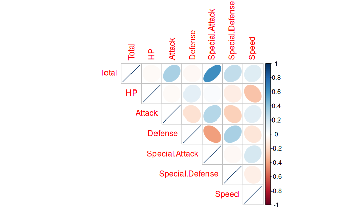

```r
library(corrplot)
corrplot(mat_cor, method="ellipse", type="upper")
```

Total, Attack, Special.Attack y Speed están correlacionados positivamente entre sí.

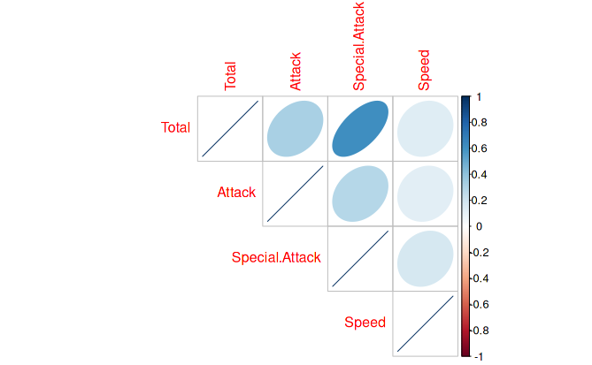

```r
pok.scale.2 <- pok.scale%>%select(Total, Attack, Special.Attack, Speed)
mat_cor2<-cor(pok.scale.2, method="kendall" )
corrplot(mat_cor2, method = "ellipse", type = "upper")
```

#### Visualización de los datos

```r
library(ggplot2)
```

Estandarizados

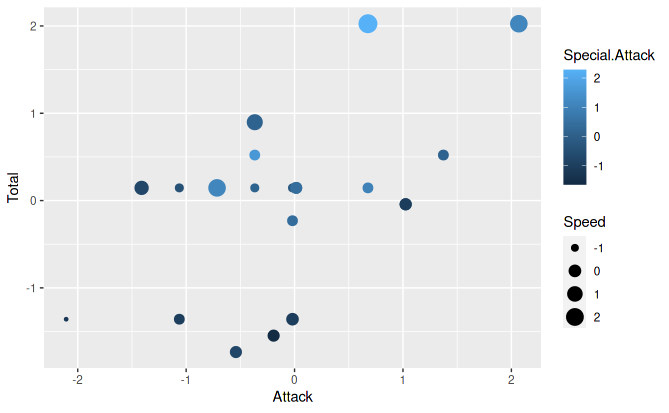

```r
ggplot(pok.scale.2,aes(Attack, Total, color=Special.Attack, size=Speed))+geom_point()
```

Sin estandarizar

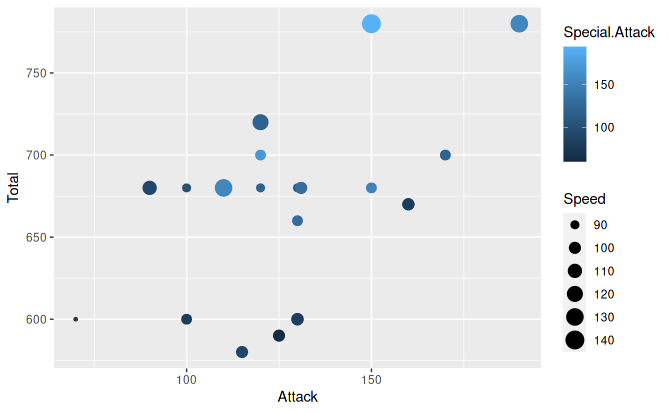

```r
ggplot(pok,aes(Attack, Total, color=Special.Attack, size=Speed))+geom_point()
```

#### Clúster jerárquico

Usando distancias euclideanas y método de medias

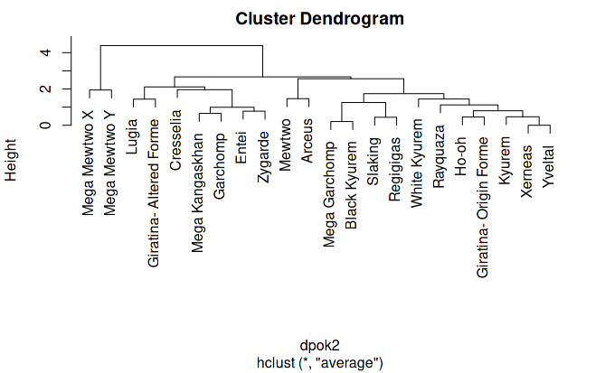

```r
dpok2<-dist(pok.scale.2, method = "euclidean")
clusterpok2<-hclust(dpok2, method = "average")
plot(clusterpok2, labels=pok[,1])
```

#### Visualización de datos y clusters (dependiendo de dónde se corte el dendrograma será el número de clusters)

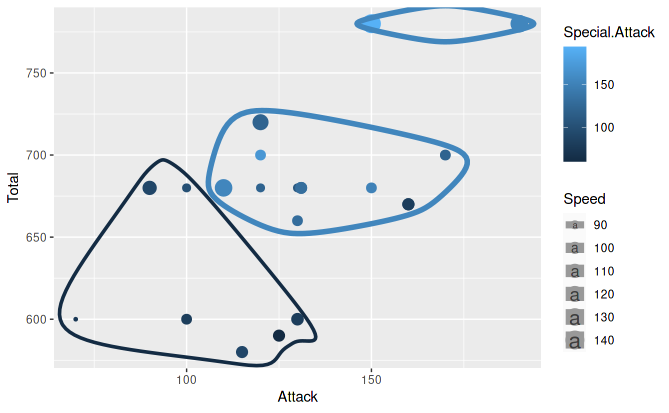

```r
library(ggalt) #para encerrar los puntos con geom_encircle()
library(ggrepel) #para poner etiquetas con geom_label_repel()

#Si existen problemas con la instalacion de la paquetería ggalt se recomienda consultar:
#https://community.rstudio.com/t/install-ggalt-from-github-without-installing-proj4/35260

#cortar el dendrograma
asignaciones<-cutree(clusterpok2, h=2.6)
pok.clustered<- pok%>%select(Total, Attack, Special.Attack, Speed, Type, Name)%>%mutate(cluster=asignaciones)

#visualizar
ggplot(pok.clustered,aes(Attack, Total, color=Special.Attack, size=Speed))+
  geom_point()+
  geom_encircle(group=factor(asignaciones), spread=1e-2, expand=0.04)+
  geom_label_repel(label=pok$Name, max.overlaps = 15, alpha=0.6)
```

#### Visualización del dendrograma con el corte

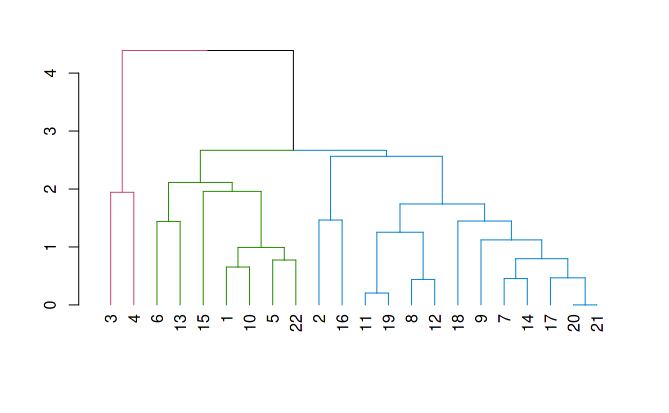

```r
library(dendextend)
dendrograma<-as.dendrogram(clusterpok2)
dendrograma_color<-color_branches(dendrograma, h=2.6)
plot(dendrograma_color)
```

#### Contar los pokémons de cada tipo por clúster

##### Clúster 1

```r
cluster1 <- pok.clustered %>% filter(cluster==1)
glimpse(cluster1)
```

```
Rows: 7
Columns: 7
$ Total          <int> 590, 580, 680, 600, 680, 600, 600
$ Attack         <int> 125, 115, 90, 130, 100, 70, 100
$ Special.Attack <int> 60, 90, 90, 80, 100, 75, 81
$ Speed          <int> 100, 100, 110, 102, 90, 85, 95
$ Type           <chr> "NORMAL", "FIRE", "PSYCHIC", "DRAGON", "GH…
$ Name           <chr> "Mega Kangaskhan", "Entei", "Lugia", "Garc…
$ cluster        <int> 1, 1, 1, 1, 1, 1, 1
```

```r
cluster1 %>% count(Type, sort=T)
```

| Type | n |
| --- | --- |
| DRAGON | 2 |
| PSYCHIC | 2 |
| FIRE | 1 |
| GHOST | 1 |
| NORMAL | 1 |

##### Clúster 2

```r
cluster2 <- pok.clustered %>% filter(cluster==2)
glimpse(cluster2)
```

```
Rows: 13
Columns: 7
$ Total          <int> 680, 680, 670, 680, 700, 670, 680, 720, 66…
$ Attack         <int> 110, 130, 160, 150, 170, 160, 120, 120, 13…
$ Special.Attack <int> 154, 110, 95, 150, 120, 80, 120, 120, 130,…
$ Speed          <int> 130, 90, 100, 95, 92, 100, 90, 120, 95, 95…
$ Type           <chr> "PSYCHIC", "FIRE", "NORMAL", "DRAGON", "DR…
$ Name           <chr> "Mewtwo", "Ho-oh", "Slaking", "Rayquaza", …
$ cluster        <int> 2, 2, 2, 2, 2, 2, 2, 2, 2, 2, 2, 2, 2
```

```r
cluster2 %>% count(Type, sort=T)
```

| Type | n |
| --- | --- |
| DRAGON | 5 |
| NORMAL | 3 |
| DARK | 1 |
| FAIRY | 1 |
| FIRE | 1 |
| GHOST | 1 |
| PSYCHIC | 1 |

##### Clúster 3

```r
cluster3 <- pok.clustered %>% filter(cluster==3)
glimpse(cluster3)
```

```
Rows: 2
Columns: 7
$ Total          <int> 780, 780
$ Attack         <int> 190, 150
$ Special.Attack <int> 154, 194
$ Speed          <int> 130, 140
$ Type           <chr> "PSYCHIC", "PSYCHIC"
$ Name           <chr> "Mega Mewtwo X", "Mega Mewtwo Y"
$ cluster        <int> 3, 3
```

```r
cluster3 %>% count(Type, sort=T)
```

| Type | n |
| --- | --- |
| PSYCHIC | 2 |

#### Conclusión del análisis con clúster jerárquico basado en variables correlacionadas positivamente entre sí

Los pokémons en el clúster 3 tienen características que en general, comparados con los de los clústers 1 y 2 los hacen más fuertes, ambos son de tipo PSYCHIC.

Dentro del clúster 2 están la mayoría de los pokémons seleccionados y puede decirse que son pokémons fuertes pero no son los más fuertes de todos los elegidos, la mayoría de este grupo son de tipo DRAGON.

Por último, en el clúster 1 se encuentran los pokémons menos fuertes del grupo seleccionado (recordando: HP>100 y Total>550) y la mayoría son DRAGON o PSYCHIC.

### Analisis de Clúster(k-means)

Paqueterias utilizadas

```r
ipak <- function(pkg){
    new.pkg <- pkg[!(pkg %in% installed.packages()[, "Package"])]
    if (length(new.pkg))
        install.packages(new.pkg, dependencies = TRUE)
    sapply(pkg, require, character.only = TRUE)
}

paquetes <- c("tidyverse","cluster","factoextra","NbClust","tidyr","dplyr")
ipak(paquetes)
```

```
 tidyverse    cluster factoextra    NbClust      tidyr      dplyr
      TRUE       TRUE       TRUE       TRUE       TRUE       TRUE
```

[figure not shown]

```r
# Cluster
pokCluster<-scale(pok[,4:9])
rownames(pokCluster) <- pok$Name
#calcular la matriz de distacias
m.distancia <- get_dist(pokCluster, method =  "euclidean")
#el método aceptado también puede ser: "maximum", "manhattan", "canberra", "binary", "minkowski", "pearson", "spearman" o "kendall"
fviz_dist(m.distancia, gradient = list(low = "blue", mid = "white", high = "red"))
```

Podemos observar como se relacionan las estadisticas de cada pokemon en comparacion a todos los demas, con los colores azul, blanco y rojo, poca, mediana y mucha distancia respectivamente.

Se distinguen a priori tres grupos haciendo un heatmap de distancias.

### Estimar el número de clústers (k-means)

Para calcular el número óptimo de clústers se usarán varios metodos.

#### Metodo con suma de cuadrados (Elbow)

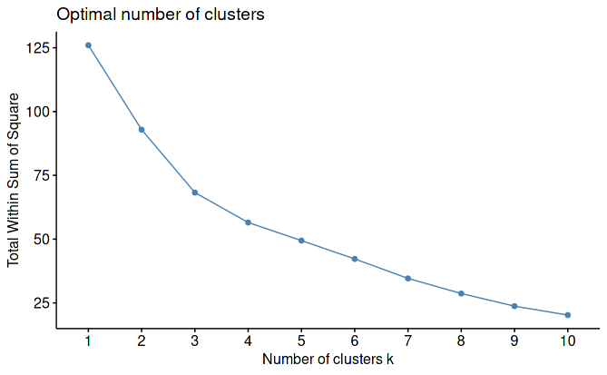

```r
# (apunta a 3 clusters, con la "rodilla o punto de corte)
fviz_nbclust(pokCluster, kmeans, method = "wss")
```

#### Metodo de la silueta.

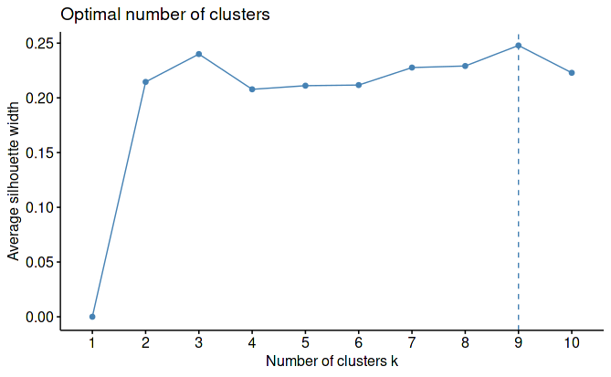

```r
# Metodo de la silueta
# (apunta a 9 clusters y seguido de 3)
fviz_nbclust(pokCluster, kmeans, method = "silhouette")
```

### Metodo estadistico Gap

[output not shown]

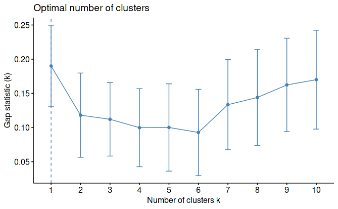

```r
# Estadística de brechas para estimar el número de clústeres
fviz_nbclust(pokCluster, kmeans, method = "gap_stat")
```

```
*** : The Hubert index is a graphical method of determining the number of clusters.
                In the plot of Hubert index, we seek a significant knee that corresponds to a
                significant increase of the value of the measure i.e the significant peak in Hubert
                index second differences plot.
```

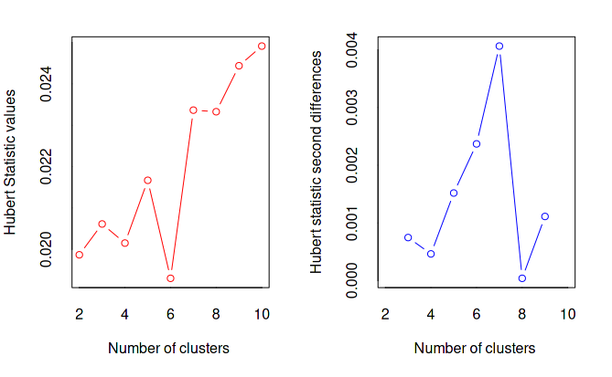

```
*** : The D index is a graphical method of determining the number of clusters.
                In the plot of D index, we seek a significant knee (the significant peak in Dindex
                second differences plot) that corresponds to a significant increase of the value of
                the measure.

* Among all indices:
* 6 proposed 2 as the best number of clusters
* 10 proposed 3 as the best number of clusters
* 1 proposed 4 as the best number of clusters
* 1 proposed 5 as the best number of clusters
* 2 proposed 7 as the best number of clusters
* 7 proposed 10 as the best number of clusters

                   ***** Conclusion *****

* According to the majority rule, the best number of clusters is  3
```

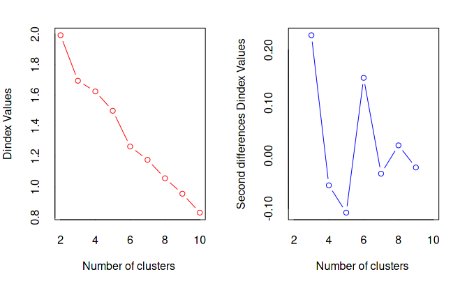

```r
#Con esta función se pueden calcular:
#the index to be calculated. This should be one of : "kl", "ch", "hartigan", "ccc", "scott",
#"marriot", "trcovw", "tracew", "friedman", "rubin", "cindex", "db", "silhouette", "duda",
#"pseudot2", "beale", "ratkowsky", "ball", "ptbiserial", "gap", "frey", "mcclain", "gamma",
#"gplus", "tau", "dunn", "hubert", "sdindex", "dindex", "sdbw", "all" (all indices except GAP,
#Gamma, Gplus and Tau), "alllong" (all indices with Gap, Gamma, Gplus and Tau included).
pokCluster<-as.data.frame(pokCluster)
resnumclust <- NbClust(pokCluster, distance = "euclidean", min.nc=2, max.nc=10, method = "kmeans", index = "alllong")
```

```
Among all indices:
===================
* 2 proposed  0 as the best number of clusters
* 1 proposed  1 as the best number of clusters
* 6 proposed  2 as the best number of clusters
* 10 proposed  3 as the best number of clusters
* 1 proposed  4 as the best number of clusters
* 1 proposed  5 as the best number of clusters
* 2 proposed  7 as the best number of clusters
* 7 proposed  10 as the best number of clusters

Conclusion
=========================
* According to the majority rule, the best number of clusters is  3 .
```

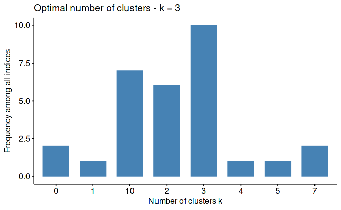

```r
fviz_nbclust(resnumclust)
```

Con esta informacion junto con todos los graficos y su respectivo metodo, notemos que al menos 10 de los metodos indican un k=3, se optó por elegir tres clusters.

### Calculamos los tres clústers

```r
#calculamos los tres clústers
k3 <- kmeans(pokCluster, centers = 3, nstart = 25)
k3
```

```
K-means clustering with 3 clusters of sizes 3, 8, 11

Cluster means:
          HP     Attack    Defense Special.Attack Special.Defense
1 -0.8253868  0.6769209 -0.9877101      1.4997329      -0.0116410
2 -0.1875194 -0.6496384  0.8637309     -0.7802695       0.8715342
3  0.3614833  0.2878495 -0.3587924      0.1584506      -0.6306682
       Speed
1  2.1163172
2 -0.2469382
3 -0.3975860

Clustering vector:
        Mega Kangaskhan                  Mewtwo
                      2                       1
          Mega Mewtwo X           Mega Mewtwo Y
                      1                       1
                  Entei                   Lugia
                      3                       2
                  Ho-oh                 Slaking
                      2                       3
               Rayquaza                Garchomp
                      3                       3
          Mega Garchomp               Regigigas
                      3                       2
Giratina- Altered Forme  Giratina- Origin Forme
                      2                       3
              Cresselia                  Arceus
                      2                       2
                 Kyurem            White Kyurem
                      3                       3
           Black Kyurem                 Xerneas
                      3                       3
                Yveltal                 Zygarde
                      3                       2

Within cluster sum of squares by cluster:
[1]  8.214861 32.943728 27.096065
 (between_SS / total_SS =  45.8 %)

Available components:

[1] "cluster"      "centers"      "totss"        "withinss"
[5] "tot.withinss" "betweenss"    "size"         "iter"
[9] "ifault"
```

```r
str(k3)
```

```
List of 9
 $ cluster     : Named int [1:22] 2 1 1 1 3 2 2 3 3 3 ...
  ..- attr(*, "names")= chr [1:22] "Mega Kangaskhan" "Mewtwo" "Mega Mewtwo X" "Mega Mewtwo Y" ...
 $ centers     : num [1:3, 1:6] -0.825 -0.188 0.361 0.677 -0.65 ...
  ..- attr(*, "dimnames")=List of 2
  .. ..$ : chr [1:3] "1" "2" "3"
  .. ..$ : chr [1:6] "HP" "Attack" "Defense" "Special.Attack" ...
 $ totss       : num 126
 $ withinss    : num [1:3] 8.21 32.94 27.1
 $ tot.withinss: num 68.3
 $ betweenss   : num 57.7
 $ size        : int [1:3] 3 8 11
 $ iter        : int 2
 $ ifault      : int 0
 - attr(*, "class")= chr "kmeans"
```

[figure not shown]

```r
fviz_cluster(k3, data = pokCluster)
```

```
Too few points to calculate an ellipse
```

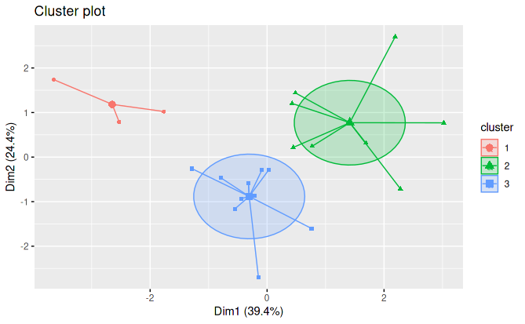

```r
fviz_cluster(k3, data = pokCluster, ellipse.type = "euclid",repel = TRUE,star.plot = TRUE) #ellipse.type= "t", "norm", "euclid"
```

Notemos que de los 3 clústers generados, uno de ellos esta conformado por Mewtwo, Mega Mewtwo X , Mega Mewtwo Y , como se había mencionado al principio, no solo a priori es considerado como de los mas fuertes a modo de creencia, si no que sus estadisticas dentro del videojuego son mayores a comparacion a los demas grupos teniendo un Cluster propio.

El cluster verde podemos catalogarlos como pokemon equilibrados en cuanto a sus estadísticas y el azul como a los pokemon más debiles de esta muestra.

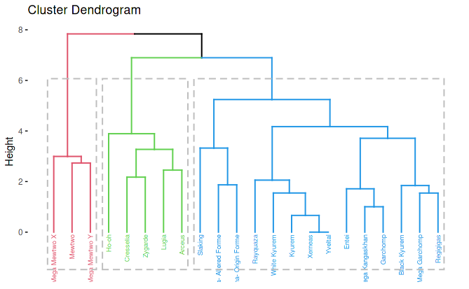

```r
# Realizar un endograma
res3 <- hcut(pokCluster, k = 3, stand = TRUE)
fviz_dend(res3, rect = TRUE, cex = 0.5,k_colors = c(2:5))
```

Con este endograma notemos como se ordenan apartir de las estadisticas de los Pokémon, haciendo uso de los clústers generados que van desde los mas fuertes a los mas debiles.

```r
# Informacion medias por cluster no estandarizados
pok[,3:9] %>%
    mutate(Cluster = k3$cluster) %>%
    group_by(Cluster) %>%
    summarise_all("mean")
```

| Cluster | Total | HP | Attack | Defense | Special.Attack | Special.Defense | Speed |
| --- | --- | --- | --- | --- | --- | --- | --- |
| 1 | 746.6667 | 106.0000 | 150.0000 | 86.66667 | 167.3333 | 103.33333 | 133.33333 |
| 2 | 652.5000 | 115.6250 | 111.8750 | 113.87500 | 89.5000 | 122.87500 | 98.75000 |
| 3 | 666.3636 | 123.9091 | 138.8182 | 95.90909 | 121.5455 | 89.63636 | 96.54545 |

```r
# Informacion medias por cluster estandarizados
pokCluster %>%
    mutate(Cluster = k3$cluster) %>%
    group_by(Cluster) %>%
    summarise_all("mean")
```

| Cluster | HP | Attack | Defense | Special.Attack | Special.Defense | Speed |
| --- | --- | --- | --- | --- | --- | --- |
| 1 | -0.8253868 | 0.6769209 | -0.9877101 | 1.4997329 | -0.0116410 | 2.1163172 |
| 2 | -0.1875194 | -0.6496384 | 0.8637309 | -0.7802695 | 0.8715342 | -0.2469382 |
| 3 | 0.3614833 | 0.2878495 | -0.3587924 | 0.1584506 | -0.6306682 | -0.3975860 |

```r
#Pasamos las asignaciones de cluster a mi df inicial para trabajar con ellos
# Sin Datos estandarizados
pok$clus<-as.factor(k3$cluster)
pok
```

| Name | Type | Total | HP | Attack | Defense | Special.Attack | Special.Defense | Speed | clus |
| --- | --- | --- | --- | --- | --- | --- | --- | --- | --- |
| Mega Kangaskhan | NORMAL | 590 | 105 | 125 | 100 | 60 | 100 | 100 | 2 |
| Mewtwo | PSYCHIC | 680 | 106 | 110 | 90 | 154 | 90 | 130 | 1 |
| Mega Mewtwo X | PSYCHIC | 780 | 106 | 190 | 100 | 154 | 100 | 130 | 1 |
| Mega Mewtwo Y | PSYCHIC | 780 | 106 | 150 | 70 | 194 | 120 | 140 | 1 |
| Entei | FIRE | 580 | 115 | 115 | 85 | 90 | 75 | 100 | 3 |
| Lugia | PSYCHIC | 680 | 106 | 90 | 130 | 90 | 154 | 110 | 2 |
| Ho-oh | FIRE | 680 | 106 | 130 | 90 | 110 | 154 | 90 | 2 |
| Slaking | NORMAL | 670 | 150 | 160 | 100 | 95 | 65 | 100 | 3 |
| Rayquaza | DRAGON | 680 | 105 | 150 | 90 | 150 | 90 | 95 | 3 |
| Garchomp | DRAGON | 600 | 108 | 130 | 95 | 80 | 85 | 102 | 3 |

[output cut: 12 more lines]

```r
# Con Datos estandarizados
pokCluster$clus<-as.factor(k3$cluster)
pokCluster
```

|  | HP | Attack | Defense | Special.Attack | Special.Defense | Speed | clus |
| --- | --- | --- | --- | --- | --- | --- | --- |
| Mega Kangaskhan | -0.8916587 | -0.19295407 | -0.08041899 | -1.6444245 | -0.1622892 | -0.16151932 | 2 |
| Mewtwo | -0.8253868 | -0.71487903 | -0.76088736 | 1.1091544 | -0.6142339 | 1.88853358 | 1 |
| Mega Mewtwo X | -0.8253868 | 2.06872074 | -0.08041899 | 1.1091544 | -0.1622892 | 1.88853358 | 1 |
| Mega Mewtwo Y | -0.8253868 | 0.67692085 | -2.12182410 | 2.2808901 | 0.7416001 | 2.57188455 | 1 |
| Entei | -0.2289394 | -0.54090405 | -1.10112155 | -0.7656228 | -1.2921508 | -0.16151932 | 3 |
| Lugia | -0.8253868 | -1.41077897 | 1.96098612 | -0.7656228 | 2.2782119 | 0.52183165 | 2 |
| Ho-oh | -0.8253868 | -0.01897909 | -0.76088736 | -0.1797549 | 2.2782119 | -0.84487029 | 2 |
| Slaking | 2.0905782 | 1.02487082 | -0.08041899 | -0.6191558 | -1.7440955 | -0.16151932 | 3 |
| Rayquaza | -0.8916587 | 0.67692085 | -0.76088736 | 0.9919808 | -0.6142339 | -0.50319480 | 3 |
| Garchomp | -0.6928429 | -0.01897909 | -0.42065317 | -1.0585567 | -0.8402062 | -0.02484913 | 3 |

[output cut: 12 more lines]

```r
#  Vizualizacion con datos alargados y usando los Closter creados
pokCluster$clus<-factor(pokCluster$clus)
data_long <- gather(pokCluster, caracteristica, valor, HP:Speed, factor_key=TRUE)
data_long
```

| clus | caracteristica | valor |
| --- | --- | --- |
| 2 | HP | -0.89165872 |
| 1 | HP | -0.82538679 |
| 1 | HP | -0.82538679 |
| 1 | HP | -0.82538679 |
| 3 | HP | -0.22893940 |
| 2 | HP | -0.82538679 |
| 2 | HP | -0.82538679 |
| 3 | HP | 2.09057822 |
| 3 | HP | -0.89165872 |
| 3 | HP | -0.69284293 |

[output cut: 122 more lines]

```
No summary function supplied, defaulting to `mean_se()`
Warning: Removed 18 rows containing missing values (geom_segment).
```

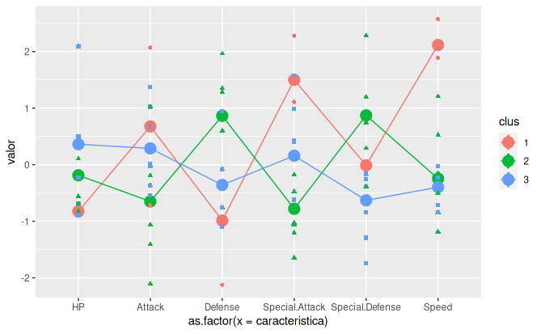

```r
ggplot(data_long, aes(as.factor(x = caracteristica), y = valor,group=clus, colour = clus)) +
    stat_summary(fun = mean, geom="pointrange", size = 1)+
    stat_summary(geom="line") +
    geom_point(aes(shape=clus))
```

### Conclusión de Clúster con k-means y medida de Distancia Euclidiana.

Los 3 clusters y sus individuos que los conforman están graficados.

- El grupo A (Más fuertes) : Son Pokémon con menor vida y defensa en comparación a los demás grupos pero destacan sobre los demás en su ataque, ataque especial y velocidad.
- El grupo B (Equilibrados): De las 6 variables podemos ver como tienen poco ataque y ataque espacial, equilibrado su HP y velocidad y destacan en defensa y defensa especial en comparación a los otros grupos.
- El grupo C (Débiles): Notemos que destacan solo en HP, por otro lado tienen poca defensa especial y velocidad.

### Conclusiones de Clúster con k-means y Clúster jerárquico.

En ambos métodos se obtuvieron tres grupos para clasificar a los Pokémons seleccionados.

### Mas allá de Pokémon

Aunque Pokémon sea un mundo ficticio rescatemos varias ideas que se toman del mundo real, una de ellas principales es la competencia y ver qué entrenador es más fuerte; en la vida real lo podemos ver en competencias de atletas o caballos, en donde cada uno de los individuos tienen características que los vuelven competitivos, cuantificables y por ende comparables.

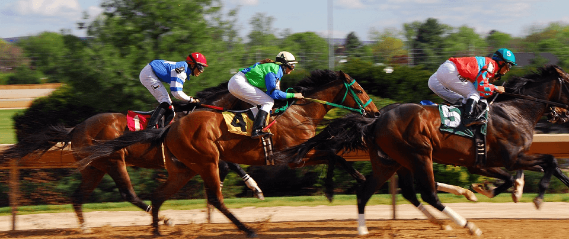

En el ejemplo de una competencia de caballos comparariamos una especie (pokémon si lo vemos de esta forma) entre ellos para hacer un análisis y ver cual es mejor; probablemente no varían tanto los datos a comparación de dos animales diferentes, caso que nos paso en este análisis y tambien pudieramos realizar un análisis PCA, NMDS o regresión lineal múltiple.

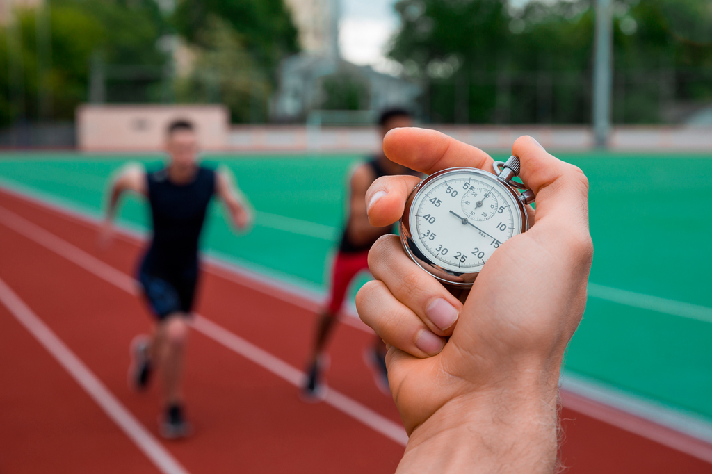

[figure not shown]

Si lo llevamos al ejemplo de una competencia de atletas, se podrían cuantificar los tiempos y puntuación para algún deporte en específico, en diferentes momentos y aunado con poder hacer mas análisis multivariados paramétricos, podriamos hacer pruebas t-student pareadas para ver comparaciones de diferentes tiempos y puntuaciones de un atleta para medir su rendimiento en una competencia.

La mecánica de capturar un pokemon y que este mejore mientras más se compite junto con su entrenador, lo podemos ver reflejado con estos ejemplos y por ende replicable.